# Project_4_Banking

## Project - 4

Domain : Banking

Description : Direct marketing campaings of Portuguese banking instituion.

Objective : The Classification goal is to predict if the client will subscribe term deposit (yes/no)

Author : Ragu RAVICHANDRAN

======================================================================================================

Importing Libraries

```python
# Basic Libraries
import numpy as np
import pandas as pd
import matplotlib.pyplot as plt
import seaborn as sns
%matplotlib inline
```

```python
# Libraries for data split for train & test and Supervised Learning models
from sklearn.model_selection import train_test_split
from sklearn.linear_model import LogisticRegression
from sklearn.naive_bayes import GaussianNB
from sklearn.neighbors import KNeighborsClassifier
from sklearn.svm import SVC
```

```python
# Libraries for supervised learning ensemble technique
from sklearn.tree import DecisionTreeClassifier
from sklearn.ensemble import BaggingClassifier
from sklearn.ensemble import AdaBoostClassifier
from sklearn.ensemble import GradientBoostingClassifier
from sklearn.ensemble import RandomForestClassifier
```

```python
# Packages for Score analysis
from sklearn import metrics
from sklearn.metrics import accuracy_score
from sklearn.metrics import precision_score
from sklearn.metrics import confusion_matrix
from sklearn.metrics import classification_report
from sklearn.metrics import recall_score
from sklearn.metrics import roc_auc_score
```

```python
# Libraries to scale the dataset where there is unequal count of Target values
from sklearn import preprocessing
from sklearn.preprocessing import MinMaxScaler, StandardScaler
from sklearn.preprocessing import LabelEncoder
from sklearn.utils import resample
```

```python
from scipy import stats
```

Load given dataset into dataframe

```python
bank = pd.read_csv('bank-full.csv')
```

Displays the top 5 records from the dataframe

```python
bank.head(5)
```

|  | age | job | marital | education | default | balance | housing | loan | contact | day | month | duration | campaign | pdays | previous | poutcome | Target |
| --- | --- | --- | --- | --- | --- | --- | --- | --- | --- | --- | --- | --- | --- | --- | --- | --- | --- |
| 0 | 58 | management | married | tertiary | no | 2143 | yes | no | unknown | 5 | may | 261 | 1 | -1 | 0 | unknown | no |
| 1 | 44 | technician | single | secondary | no | 29 | yes | no | unknown | 5 | may | 151 | 1 | -1 | 0 | unknown | no |
| 2 | 33 | entrepreneur | married | secondary | no | 2 | yes | yes | unknown | 5 | may | 76 | 1 | -1 | 0 | unknown | no |
| 3 | 47 | blue-collar | married | unknown | no | 1506 | yes | no | unknown | 5 | may | 92 | 1 | -1 | 0 | unknown | no |
| 4 | 33 | unknown | single | unknown | no | 1 | no | no | unknown | 5 | may | 198 | 1 | -1 | 0 | unknown | no |

#### Attribute Information :

1. age (numeric)
2. job : type of job (categorical: 'admin.','bluecollar','entrepreneur','housemaid','management','retired','selfemployed','services','student','technician','unemployed','unknown')
3. marital : marital status (categorical: 'divorced','married','single','unknown'; note: 'divorced' means divorced or widowed) 4. education (categorical: 'basic.4y','basic.6y','basic.9y','high.school','illiterate','professional.cour se','university.degree','unknown')
4. default: has credit in default? (categorical: 'no','yes','unknown')
5. balance: average yearly balance, in euros (numeric)
6. housing: has housing loan? (categorical: 'no','yes','unknown')
7. loan: has personal loan? (categorical: 'no','yes','unknown')
8. contact: contact communication type (categorical: 'cellular','telephone')
9. day: last contact day of the month (numeric 1 -31)
10. month: last contact month of year (categorical: 'jan', 'feb', 'mar', ..., 'nov', 'dec')
11. duration: last contact duration, in seconds (numeric). Important note: this attribute highly affects the output target (e.g., if duration=0 then y='no'). Yet, the duration is not known before a call is performed. Also, after the end of the call y is obviously known. Thus, this input should only be included for benchmark purposes and should be discarded if the intention is to have a realistic predictive model.
12. campaign: number of contacts performed during this campaign and for this client (numeric, includes last contact)
13. pdays: number of days that passed by after the client was last contacted from a previous campaign (numeric; 999 means client was not previously contacted (This should be -1))
14. previous: number of contacts performed before this campaign and for this client (numeric)
15. poutcome: outcome of the previous marketing campaign (categorical: 'failure','nonexistent','success')
16. target: has the client subscribed a term deposit? (binary: "yes","no")

Analyzing on the feature datatypes

```python
bank.info()
```

```
<class 'pandas.core.frame.DataFrame'>
RangeIndex: 45211 entries, 0 to 45210
Data columns (total 17 columns):
age          45211 non-null int64
job          45211 non-null object
marital      45211 non-null object
education    45211 non-null object
default      45211 non-null object
balance      45211 non-null int64
housing      45211 non-null object
loan         45211 non-null object
contact      45211 non-null object
day          45211 non-null int64
month        45211 non-null object
duration     45211 non-null int64
campaign     45211 non-null int64
pdays        45211 non-null int64
previous     45211 non-null int64
poutcome     45211 non-null object
Target       45211 non-null object
dtypes: int64(7), object(10)
memory usage: 5.9+ MB
```

1. Most of the features are categorical in nature in the given dataset 2. We have good number of records for model prediction 3. No variables has null/missing values, but looking at the dataset there are some values filled with unknown/

Analyze on the 5 point summary

```python
bank.describe().transpose()
```

|  | count | mean | std | min | 25% | 50% | 75% | max |
| --- | --- | --- | --- | --- | --- | --- | --- | --- |
| age | 45211.0 | 40.936210 | 10.618762 | 18.0 | 33.0 | 39.0 | 48.0 | 95.0 |
| balance | 45211.0 | 1362.272058 | 3044.765829 | -8019.0 | 72.0 | 448.0 | 1428.0 | 102127.0 |
| day | 45211.0 | 15.806419 | 8.322476 | 1.0 | 8.0 | 16.0 | 21.0 | 31.0 |
| duration | 45211.0 | 258.163080 | 257.527812 | 0.0 | 103.0 | 180.0 | 319.0 | 4918.0 |
| campaign | 45211.0 | 2.763841 | 3.098021 | 1.0 | 1.0 | 2.0 | 3.0 | 63.0 |
| pdays | 45211.0 | 40.197828 | 100.128746 | -1.0 | -1.0 | -1.0 | -1.0 | 871.0 |
| previous | 45211.0 | 0.580323 | 2.303441 | 0.0 | 0.0 | 0.0 | 0.0 | 275.0 |

```python
bank.describe(include=['object']).T
```

|  | count | unique | top | freq |
| --- | --- | --- | --- | --- |
| job | 45211 | 12 | blue-collar | 9732 |
| marital | 45211 | 3 | married | 27214 |
| education | 45211 | 4 | secondary | 23202 |
| default | 45211 | 2 | no | 44396 |
| housing | 45211 | 2 | yes | 25130 |
| loan | 45211 | 2 | no | 37967 |
| contact | 45211 | 3 | cellular | 29285 |
| month | 45211 | 12 | may | 13766 |
| poutcome | 45211 | 4 | unknown | 36959 |
| Target | 45211 | 2 | no | 39922 |

```python
bank.shape
```

```
(45211, 17)
```

```python
bank.isnull().values.any()
```

```
False
```

```python
bank['Target'].value_counts()
```

```
no     39922
yes     5289
Name: Target, dtype: int64
```

```python
bank_new = bank.rename(columns = {'housing':'housing_loan', 'loan':'personal_loan'})
bank_new.head(2)
```

|  | age | job | marital | education | default | balance | housing_loan | personal_loan | contact | day | month | duration | campaign | pdays | previous | poutcome | Target |
| --- | --- | --- | --- | --- | --- | --- | --- | --- | --- | --- | --- | --- | --- | --- | --- | --- | --- |
| 0 | 58 | management | married | tertiary | no | 2143 | yes | no | unknown | 5 | may | 261 | 1 | -1 | 0 | unknown | no |
| 1 | 44 | technician | single | secondary | no | 29 | yes | no | unknown | 5 | may | 151 | 1 | -1 | 0 | unknown | no |

```python
column_index=bank_new.describe(exclude=['int64','float64']).columns.tolist()
column_index
```

```
['job',
 'marital',
 'education',
 'default',
 'housing_loan',
 'personal_loan',
 'contact',
 'month',
 'poutcome',
 'Target']
```

```python
#for col in column_index:
#    print("Column name : ", col.upper())
#    print(bank[col].value_counts(), '\n')
def disp_uniq_counts(x=''):
    if not x:
        for col in column_index:
            tmp_dict = dict()
            tmp_dict['Column'] = col.upper()
            val_list = bank_new[col].unique()
            for uVal in val_list:
                tmp_dict[uVal] = bank_new[bank_new[col] == uVal][col].count()
            result = pd.DataFrame(tmp_dict, index=[0])
            print(result, '\n')
            print("==========================================================")
    else :
        tmp_dict = dict()
        col = x
        tmp_dict['Column'] = col.upper()
        val_list = bank_new[col].unique()
        for uVal in val_list:
            tmp_dict[uVal] = bank_new[bank_new[col] == uVal][col].count()
        result = pd.DataFrame(tmp_dict, index=[0])
        print(result, '\n')
        print("==========================================================")

disp_uniq_counts()
```

```
  Column  management  technician  entrepreneur  blue-collar  unknown  retired  \
0    JOB        9458        7597          1487         9732      288     2264

   admin.  services  self-employed  unemployed  housemaid  student
0    5171      4154           1579        1303       1240      938

==========================================================
    Column  married  single  divorced
0  MARITAL    27214   12790      5207

==========================================================
      Column  tertiary  secondary  unknown  primary
0  EDUCATION     13301      23202     1857     6851

==========================================================
    Column     no  yes
0  DEFAULT  44396  815

==========================================================
         Column    yes     no
0  HOUSING_LOAN  25130  20081

==========================================================
          Column     no   yes
0  PERSONAL_LOAN  37967  7244

==========================================================
    Column  unknown  cellular  telephone
0  CONTACT    13020     29285       2906

==========================================================
  Column    may   jun   jul   aug  oct   nov  dec   jan   feb  mar   apr  sep
0  MONTH  13766  5341  6895  6247  738  3970  214  1403  2649  477  2932  579

==========================================================
     Column  unknown  failure  other  success
0  POUTCOME    36959     4901   1840     1511

==========================================================
   Column     no   yes
0  TARGET  39922  5289

==========================================================
```

1. Columns like ('Job','Education','Contact','poutcome') have 'unknown' values

```python
bank_new.job.replace(('admin.'), ('admin'), inplace=True)
```

```python
nominal = ['default', 'housing_loan', 'personal_loan', 'Target']

y_n_cat = ['no','yes']

def check_unique_vals(col):
    uniq_val = list(bank_new[col].unique())
    return uniq_val

def compare_unique(ret_list):
    check =  all(item in y_n_cat for item in ret_list)
    return check

for col in nominal:
    ret_list = check_unique_vals(col)

    if ret_list:
        if compare_unique(ret_list):
            bank_new[col] = np.where(bank_new[col] == 'yes', 1, 0)
    else:
        print ('No list returned form check_unique_vals()')

bank_new.head(5)
```

|  | age | job | marital | education | default | balance | housing_loan | personal_loan | contact | day | month | duration | campaign | pdays | previous | poutcome | Target |
| --- | --- | --- | --- | --- | --- | --- | --- | --- | --- | --- | --- | --- | --- | --- | --- | --- | --- |
| 0 | 58 | management | married | tertiary | 0 | 2143 | 1 | 0 | unknown | 5 | may | 261 | 1 | -1 | 0 | unknown | 0 |
| 1 | 44 | technician | single | secondary | 0 | 29 | 1 | 0 | unknown | 5 | may | 151 | 1 | -1 | 0 | unknown | 0 |
| 2 | 33 | entrepreneur | married | secondary | 0 | 2 | 1 | 1 | unknown | 5 | may | 76 | 1 | -1 | 0 | unknown | 0 |
| 3 | 47 | blue-collar | married | unknown | 0 | 1506 | 1 | 0 | unknown | 5 | may | 92 | 1 | -1 | 0 | unknown | 0 |
| 4 | 33 | unknown | single | unknown | 0 | 1 | 0 | 0 | unknown | 5 | may | 198 | 1 | -1 | 0 | unknown | 0 |

1. Replaced the Yes/No values with 1/0 respectively for the columns ['default', 'housing_loan', 'personal_loan', 'Target']

Checking the column values after the change

```python
for col in nominal:
    ret_list = check_unique_vals(col)
    if ret_list:
        print (col + ":" + str(ret_list))
```

```
default:[0, 1]
housing_loan:[1, 0]
personal_loan:[0, 1]
Target:[0, 1]
```

```python
# Currently 2 dataframes available
# 1. bank with original column names and values
# 2. bank_new with binary values like (yes, no) changed to (1,0) respectively
```

```python
bank_new.head(2)
```

|  | age | job | marital | education | default | balance | housing_loan | personal_loan | contact | day | month | duration | campaign | pdays | previous | poutcome | Target |
| --- | --- | --- | --- | --- | --- | --- | --- | --- | --- | --- | --- | --- | --- | --- | --- | --- | --- |
| 0 | 58 | management | married | tertiary | 0 | 2143 | 1 | 0 | unknown | 5 | may | 261 | 1 | -1 | 0 | unknown | 0 |
| 1 | 44 | technician | single | secondary | 0 | 29 | 1 | 0 | unknown | 5 | may | 151 | 1 | -1 | 0 | unknown | 0 |

Replace the month to numbers

```python
disp_uniq_counts('month')
```

```
  Column    may   jun   jul   aug  oct   nov  dec   jan   feb  mar   apr  sep
0  MONTH  13766  5341  6895  6247  738  3970  214  1403  2649  477  2932  579

==========================================================
```

```python
disp_uniq_counts('job')
```

```
  Column  management  technician  entrepreneur  blue-collar  unknown  retired  \
0    JOB        9458        7597          1487         9732      288     2264

   admin  services  self-employed  unemployed  housemaid  student
0   5171      4154           1579        1303       1240      938

==========================================================
```

```python
disp_uniq_counts('marital')
```

```
    Column  married  single  divorced
0  MARITAL    27214   12790      5207

==========================================================
```

```python
disp_uniq_counts('education')
```

```
      Column  tertiary  secondary  unknown  primary
0  EDUCATION     13301      23202     1857     6851

==========================================================
```

```python
disp_uniq_counts('contact')
```

```
    Column  unknown  cellular  telephone
0  CONTACT    13020     29285       2906

==========================================================
```

```python
disp_uniq_counts('poutcome')
```

```
     Column  unknown  failure  other  success
0  POUTCOME    36959     4901   1840     1511

==========================================================
```

```python
import calendar
month_dict = {v.lower() : int(k) for k,v in enumerate(calendar.month_abbr)}
month_dict
```

```
{'': 0,
 'jan': 1,
 'feb': 2,
 'mar': 3,
 'apr': 4,
 'may': 5,
 'jun': 6,
 'jul': 7,
 'aug': 8,
 'sep': 9,
 'oct': 10,
 'nov': 11,
 'dec': 12}
```

```python
month_dict.keys()
```

```
dict_keys(['', 'jan', 'feb', 'mar', 'apr', 'may', 'jun', 'jul', 'aug', 'sep', 'oct', 'nov', 'dec'])
```

```python
# bank_new['month'] = bank_new['month'].apply(lambda x: month_dict.get(x))
# bank_new['month'].unique()

#for key in month_dict.keys():
#    if key:
#        bank_new['month'] = np.where(bank_new['month'] == key, month_dict.get(key))
bank_new['month'] = bank_new['month'].apply(lambda x: month_dict.get(x) if bank_new['month'].dtypes != 'int64' else x)
```

```python
disp_uniq_counts('month')
```

```
  Column      5     6     7     8   10    11   12     1     2    3     4    9
0  MONTH  13766  5341  6895  6247  738  3970  214  1403  2649  477  2932  579

==========================================================
```

```python
bank_new['Target'].unique()
```

```
array([0, 1], dtype=int64)
```

```python
bank_new[['month', 'Target']].groupby(['month'], as_index=False).mean()
```

|  | month | Target |
| --- | --- | --- |
| 0 | 1 | 0.101212 |
| 1 | 2 | 0.166478 |
| 2 | 3 | 0.519916 |
| 3 | 4 | 0.196794 |
| 4 | 5 | 0.067195 |
| 5 | 6 | 0.102228 |
| 6 | 7 | 0.090935 |
| 7 | 8 | 0.110133 |
| 8 | 9 | 0.464594 |
| 9 | 10 | 0.437669 |
| 10 | 11 | 0.101511 |
| 11 | 12 | 0.467290 |

Replacing unknown values as much as possible based on the other features

```python
data = []
def balance_depends_edu(level):
    minB = bank_new[bank_new['education'] == level]['balance'].min()
    maxB = bank_new[bank_new['education'] == level]['balance'].max()
    meanB = bank_new[bank_new['education'] == level]['balance'].mean()
    mediB = bank_new[bank_new['education'] == level]['balance'].median()

    data = [{'Education':level,'min_bal':minB,'max_bal':maxB,'mean_bal':meanB,'median_bal':mediB}]
    return data
```

```python
edu_uniq_list = list(bank_new['education'].unique())
for edu_lvl in edu_uniq_list:
    data = balance_depends_edu(edu_lvl)

    df = pd.DataFrame(data)
    #print (pd.DataFrame(data).style.hide_index().highlight_max(color='lightgreen').highlight_min(color='#cd4f39'), '\n')
    print (df, '\n')
```

```
  Education  max_bal     mean_bal  median_bal  min_bal
0  tertiary   102127  1758.416435       577.0    -6847

   Education  max_bal     mean_bal  median_bal  min_bal
0  secondary    81204  1154.880786       392.0    -8019

  Education  max_bal     mean_bal  median_bal  min_bal
0   unknown    64343  1526.754443       568.0    -1445

  Education  max_bal     mean_bal  median_bal  min_bal
0   primary    71188  1250.949934       403.0    -2604
```

```python
bank_new.info()
```

```
<class 'pandas.core.frame.DataFrame'>
RangeIndex: 45211 entries, 0 to 45210
Data columns (total 17 columns):
age              45211 non-null int64
job              45211 non-null object
marital          45211 non-null object
education        45211 non-null object
default          45211 non-null int32
balance          45211 non-null int64
housing_loan     45211 non-null int32
personal_loan    45211 non-null int32
contact          45211 non-null object
day              45211 non-null int64
month            45211 non-null int64
duration         45211 non-null int64
campaign         45211 non-null int64
pdays            45211 non-null int64
previous         45211 non-null int64
poutcome         45211 non-null object
Target           45211 non-null int32
dtypes: int32(4), int64(8), object(5)
memory usage: 5.2+ MB
```

```python
from IPython.display import display
display(pd.crosstab(bank_new['job'], bank_new['Target']).T)

display(pd.crosstab(bank_new['marital'], bank_new['Target']).T)

display(pd.crosstab(bank_new['education'], bank_new['Target']).T)

display(pd.crosstab(bank_new['contact'], bank_new['Target']).T)

display(pd.crosstab(bank_new['poutcome'], bank_new['Target']).T)
```

| job Target | admin | blue-collar | entrepreneur | housemaid | management | retired | self-employed | services | student | technician | unemployed | unknown |
| --- | --- | --- | --- | --- | --- | --- | --- | --- | --- | --- | --- | --- |
| 0 | 4540 | 9024 | 1364 | 1131 | 8157 | 1748 | 1392 | 3785 | 669 | 6757 | 1101 | 254 |
| 1 | 631 | 708 | 123 | 109 | 1301 | 516 | 187 | 369 | 269 | 840 | 202 | 34 |

| marital Target | divorced | married | single |
| --- | --- | --- | --- |
| 0 | 4585 | 24459 | 10878 |
| 1 | 622 | 2755 | 1912 |

| education Target | primary | secondary | tertiary | unknown |
| --- | --- | --- | --- | --- |
| 0 | 6260 | 20752 | 11305 | 1605 |
| 1 | 591 | 2450 | 1996 | 252 |

| contact Target | cellular | telephone | unknown |
| --- | --- | --- | --- |
| 0 | 24916 | 2516 | 12490 |
| 1 | 4369 | 390 | 530 |

| poutcome Target | failure | other | success | unknown |
| --- | --- | --- | --- | --- |
| 0 | 4283 | 1533 | 533 | 33573 |
| 1 | 618 | 307 | 978 | 3386 |

1. From the above grouping we can see the majority of people are married. 2. On the education feature - there are more number of people who had secondary education. 3. For Job feature - blue-collar, management and technicians are more compared to other job categories

```python
bank_new[(bank['age'] >= 60) & (bank['job'] == 'unknown')]['age'].count()
```

```
28
```

```python
bank_new[((bank_new['age'] >= 40) & (bank['age'] < 60)) & (bank['job'] == 'unknown')]['age'].count()
```

```
192
```

```python
job_list=bank_new[bank_new['education'] == 'unknown']['job'].unique()
def return_edu_for_job(job):
    bn = bank_new[bank_new['job']==job]['education'].value_counts()
    return bn[bn == bn.max()].index[0]
```

```python
bank_new.loc[(bank_new['age']>60) & (bank_new['job']=='unknown'), 'job'] = 'retired'
for job in job_list:
    if job != 'unknown':
        bank_new.loc[(bank_new['education']=='unknown') & (bank_new['job']==job), 'education'] = return_edu_for_job(job)
```

```python
disp_uniq_counts('education')
```

```
      Column  tertiary  secondary  unknown  primary
0  EDUCATION     13658      24541      116     6896

==========================================================
```

```python
## The rest of the unknown values in education are replaced with secondary education level which is higher in the dataset.
bank_new.education.replace(('unknown'), ('secondary'), inplace=True)
```

```python
disp_uniq_counts('education')
```

```
      Column  tertiary  secondary  primary
0  EDUCATION     13658      24657     6896

==========================================================
```

```python
disp_uniq_counts('job')
```

```
  Column  management  technician  entrepreneur  blue-collar  unknown  retired  \
0    JOB        9458        7597          1487         9732      266     2286

   admin  services  self-employed  unemployed  housemaid  student
0   5171      4154           1579        1303       1240      938

==========================================================
```

```python
## Here we have substituted the age and education values to get max result to fill the unknown values below.
bank_new[(bank_new['age']>=40 ) & (bank_new['age']<=60) & (bank_new['education']=='tertiary')]['job'].value_counts()
```

```
management       3393
technician        615
entrepreneur      416
self-employed     330
retired           213
admin             116
unemployed         99
housemaid          84
services           52
blue-collar        37
unknown            22
Name: job, dtype: int64
```

```python
bank_new.loc[(bank_new['age'] <= 25) & (bank_new['job']=='unknown'), 'job'] = 'student'
bank_new.loc[(bank_new['age']>25 ) & (bank_new['age']<40) & (bank_new['education'] == 'primary') & (bank_new['job']=='unknown'), 'job'] = 'blue-collar'
bank_new.loc[(bank_new['age']>25 ) & (bank_new['age']<40) & (bank_new['education'] == 'secondary') & (bank_new['job']=='unknown'), 'job'] = 'blue-collar'
bank_new.loc[(bank_new['age']>25 ) & (bank_new['age']<40) & (bank_new['education'] == 'tertiary') & (bank_new['job']=='unknown'), 'job'] = 'management'
```

```python
bank_new.loc[(bank_new['age']>=40 ) & (bank_new['age']<=60) & (bank_new['education'] == 'primary') & (bank_new['job']=='unknown'), 'job'] = 'blue-collar'
bank_new.loc[(bank_new['age']>=40 ) & (bank_new['age']<=60) & (bank_new['education'] == 'secondary') & (bank_new['job']=='unknown'), 'job'] = 'technician'
bank_new.loc[(bank_new['age']>=40 ) & (bank_new['age']<=60) & (bank_new['education'] == 'tertiary') & (bank_new['job']=='unknown'), 'job'] = 'management'
```

```python
disp_uniq_counts('job')
```

```
  Column  management  technician  entrepreneur  blue-collar  retired  admin  \
0    JOB        9492        7736          1487         9823     2286   5171

   services  self-employed  unemployed  housemaid  student
0      4154           1579        1303       1240      940

==========================================================
```

```python
### Still contact and poutcome features have the unknown values in it.
```

```python
disp_uniq_counts('contact')
```

```
    Column  unknown  cellular  telephone
0  CONTACT    13020     29285       2906

==========================================================
```

```python
disp_uniq_counts('poutcome')
```

```
     Column  unknown  failure  other  success
0  POUTCOME    36959     4901   1840     1511

==========================================================
```

We will rename the unknown values on these features as 'other'. It will be better to understand that it is some other form of communication. And the same in case of poutcome 'other' is considered as a inProgress status.

```python
bank_new['poutcome'].replace(('unknown'), ('other'), inplace=True)
```

```python
bank_new['contact'].replace(('unknown'), ('other'), inplace=True)
```

```python
bank_new['pdays'] = np.where(bank_new['pdays'] == -1,bank_new[bank_new['pdays'] > -1]['pdays'].mean(),bank_new['pdays'])
```

```python
bank_new['pdays'] = bank_new['pdays'].astype(int)
```

Replacing the -1 values in pdays feature to the mean value of rest of the pdays data.

```python
### Creating dummies on marital feature for now.
```

```python
bank_dum = pd.get_dummies(data=bank_new, columns = ['job','marital','education','contact','poutcome'], prefix = ['job','marital','education','contact','poutcome'])
bank_dum.head()
```

|  | age | default | balance | housing_loan | personal_loan | day | month | duration | campaign | pdays | ... | marital_single | education_primary | education_secondary | education_tertiary | contact_cellular | contact_other | contact_telephone | poutcome_failure | poutcome_other | poutcome_success |
| --- | --- | --- | --- | --- | --- | --- | --- | --- | --- | --- | --- | --- | --- | --- | --- | --- | --- | --- | --- | --- | --- |
| 0 | 58 | 0 | 2143 | 1 | 0 | 5 | 5 | 261 | 1 | 224 | ... | 0 | 0 | 0 | 1 | 0 | 1 | 0 | 0 | 1 | 0 |
| 1 | 44 | 0 | 29 | 1 | 0 | 5 | 5 | 151 | 1 | 224 | ... | 1 | 0 | 1 | 0 | 0 | 1 | 0 | 0 | 1 | 0 |
| 2 | 33 | 0 | 2 | 1 | 1 | 5 | 5 | 76 | 1 | 224 | ... | 0 | 0 | 1 | 0 | 0 | 1 | 0 | 0 | 1 | 0 |
| 3 | 47 | 0 | 1506 | 1 | 0 | 5 | 5 | 92 | 1 | 224 | ... | 0 | 0 | 1 | 0 | 0 | 1 | 0 | 0 | 1 | 0 |
| 4 | 33 | 0 | 1 | 0 | 0 | 5 | 5 | 198 | 1 | 224 | ... | 1 | 0 | 1 | 0 | 0 | 1 | 0 | 0 | 1 | 0 |

5 rows × 35 columns

```python
bank_dum.shape
```

```
(45211, 35)
```

```python
le = preprocessing.LabelEncoder()
bank_new.job = le.fit_transform(bank_new.job)
bank_new.marital = le.fit_transform(bank_new.marital)
bank_new.education = le.fit_transform(bank_new.education)
bank_new.contact = le.fit_transform(bank_new.contact)
bank_new.poutcome = le.fit_transform(bank_new.poutcome)
bank_new.head()
```

|  | age | job | marital | education | default | balance | housing_loan | personal_loan | contact | day | month | duration | campaign | pdays | previous | poutcome | Target |
| --- | --- | --- | --- | --- | --- | --- | --- | --- | --- | --- | --- | --- | --- | --- | --- | --- | --- |
| 0 | 58 | 4 | 1 | 2 | 0 | 2143 | 1 | 0 | 1 | 5 | 5 | 261 | 1 | 224 | 0 | 1 | 0 |
| 1 | 44 | 9 | 2 | 1 | 0 | 29 | 1 | 0 | 1 | 5 | 5 | 151 | 1 | 224 | 0 | 1 | 0 |
| 2 | 33 | 2 | 1 | 1 | 0 | 2 | 1 | 1 | 1 | 5 | 5 | 76 | 1 | 224 | 0 | 1 | 0 |
| 3 | 47 | 1 | 1 | 1 | 0 | 1506 | 1 | 0 | 1 | 5 | 5 | 92 | 1 | 224 | 0 | 1 | 0 |
| 4 | 33 | 1 | 2 | 1 | 0 | 1 | 0 | 0 | 1 | 5 | 5 | 198 | 1 | 224 | 0 | 1 | 0 |

```python
bank_new.shape
```

```
(45211, 17)
```

```python
# Now bank_new dataframe contains label encoding
# bank_dum dataframe contains dummies
```

```python
def get_correlation(data):
    return data.corr()

corr_data = get_correlation(bank_dum)
corr_data
```

|  | age | default | balance | housing_loan | personal_loan | day | month | duration | campaign | pdays | ... | marital_single | education_primary | education_secondary | education_tertiary | contact_cellular | contact_other | contact_telephone | poutcome_failure | poutcome_other | poutcome_success |
| --- | --- | --- | --- | --- | --- | --- | --- | --- | --- | --- | --- | --- | --- | --- | --- | --- | --- | --- | --- | --- | --- |
| age | 1.000000 | -0.017879 | 0.097783 | -0.185513 | -0.015655 | -0.009120 | 0.092903 | -0.004648 | 0.004760 | -0.049590 | ... | -0.427817 | 0.198766 | -0.076064 | -0.073149 | -0.068375 | -0.020132 | 0.170349 | -0.004927 | -0.013912 | 0.035526 |
| default | -0.017879 | 1.000000 | -0.066745 | -0.006025 | 0.077234 | 0.009424 | 0.014989 | -0.010021 | 0.016822 | 0.008800 | ... | 0.003115 | 0.001706 | 0.012526 | -0.014919 | -0.010061 | 0.019933 | -0.017208 | -0.026389 | 0.035542 | -0.023344 |
| balance | 0.097783 | -0.066745 | 1.000000 | -0.068768 | -0.084350 | 0.004503 | 0.094605 | 0.021560 | -0.014578 | -0.046307 | ... | -0.012537 | -0.013976 | -0.068072 | 0.084764 | 0.015880 | -0.037331 | 0.037999 | 0.011857 | -0.028721 | 0.035240 |
| housing_loan | -0.185513 | -0.006025 | -0.068768 | 1.000000 | 0.041323 | -0.027982 | -0.173887 | 0.005075 | -0.023599 | 0.139995 | ... | -0.020475 | 0.008288 | 0.087942 | -0.101858 | -0.156071 | 0.208409 | -0.080822 | 0.106795 | -0.048101 | -0.091360 |
| personal_loan | -0.015655 | 0.077234 | -0.084350 | 0.041323 | 1.000000 | 0.011370 | 0.021638 | -0.012412 | 0.009980 | 0.008826 | ... | -0.051716 | -0.013236 | 0.054408 | -0.048638 | 0.013604 | -0.007211 | -0.013183 | -0.002186 | 0.029620 | -0.053713 |
| day | -0.009120 | 0.009424 | 0.004503 | -0.027982 | 0.011370 | 1.000000 | 0.101989 | -0.030206 | 0.162490 | -0.037025 | ... | -0.007412 | -0.019575 | -0.005390 | 0.021173 | 0.020186 | -0.034103 | 0.023652 | -0.068700 | 0.076842 | -0.030321 |
| month | 0.092903 | 0.014989 | 0.094605 | -0.173887 | 0.021638 | 0.101989 | 1.000000 | -0.011866 | 0.054868 | -0.113606 | ... | -0.068586 | -0.026150 | -0.055023 | 0.080144 | 0.153677 | -0.182490 | 0.037628 | -0.055958 | 0.032504 | 0.033700 |
| duration | -0.004648 | -0.010021 | 0.021560 | 0.005075 | -0.012412 | -0.030206 | -0.011866 | 1.000000 | -0.084570 | -0.009509 | ... | 0.020328 | -0.004398 | 0.002434 | 0.000804 | 0.025543 | -0.014379 | -0.023201 | -0.018925 | -0.004974 | 0.042389 |
| campaign | 0.004760 | 0.016822 | -0.014578 | -0.023599 | 0.009980 | 0.162490 | 0.054868 | -0.084570 | 1.000000 | 0.010393 | ... | -0.023120 | 0.009444 | -0.017794 | 0.011902 | -0.032271 | 0.004853 | 0.053895 | -0.088131 | 0.108153 | -0.057486 |
| pdays | -0.049590 | 0.008800 | -0.046307 | 0.139995 | 0.008826 | -0.037025 | -0.113606 | -0.009509 | 0.010393 | 1.000000 | ... | 0.001813 | 0.028913 | 0.041639 | -0.067795 | -0.007538 | 0.012699 | -0.008766 | 0.123117 | 0.008544 | -0.229542 |
| previous | 0.001288 | -0.018329 | 0.016674 | 0.037076 | -0.011043 | -0.051710 | -0.035600 | 0.001203 | -0.032855 | -0.016104 | ... | 0.017006 | -0.016530 | -0.010164 | 0.023965 | 0.131717 | -0.154162 | 0.028097 | 0.350627 | -0.416226 | 0.201424 |
| Target | 0.025155 | -0.022419 | 0.052838 | -0.139173 | -0.068185 | -0.028348 | 0.018717 | 0.394521 | -0.073172 | -0.084503 | ... | 0.063526 | -0.040527 | -0.034067 | 0.068677 | 0.135873 | -0.150935 | 0.014042 | 0.009885 | -0.166863 | 0.306788 |
| job_admin | -0.055717 | -0.010037 | -0.026726 | 0.043046 | 0.030781 | -0.010455 | -0.034056 | -0.015722 | -0.021868 | 0.009982 | ... | 0.040912 | -0.112060 | 0.219105 | -0.149861 | 0.000660 | 0.005961 | -0.012291 | 0.018431 | -0.022636 | 0.012056 |
| job_blue-collar | -0.044027 | 0.009645 | -0.048327 | 0.172605 | 0.016683 | -0.023513 | -0.086020 | 0.009208 | 0.009242 | 0.079682 | ... | -0.087511 | 0.344562 | 0.054802 | -0.329226 | -0.130896 | 0.139073 | -0.001834 | 0.001408 | 0.026157 | -0.053206 |
| job_entrepreneur | 0.021792 | 0.026281 | 0.009642 | 0.010600 | 0.039808 | -0.002312 | 0.025128 | -0.001327 | 0.002128 | -0.002486 | ... | -0.050297 | -0.015112 | -0.066992 | 0.084481 | -0.002386 | 0.004867 | -0.004338 | 0.001119 | 0.008849 | -0.019111 |
| job_housemaid | 0.086650 | -0.000359 | 0.001661 | -0.079380 | -0.017234 | 0.003955 | 0.031249 | -0.008046 | 0.003097 | -0.017650 | ... | -0.062177 | 0.181883 | -0.076498 | -0.059459 | -0.015649 | -0.004815 | 0.039371 | -0.016300 | 0.019356 | -0.009375 |
| job_management | -0.023028 | -0.002902 | 0.068361 | -0.065036 | -0.039659 | 0.019084 | 0.080289 | -0.008619 | 0.017173 | -0.040748 | ... | 0.032888 | -0.174287 | -0.442348 | 0.616168 | 0.101489 | -0.090734 | -0.030142 | 0.003151 | -0.013980 | 0.021685 |
| job_retired | 0.450995 | -0.011540 | 0.046738 | -0.158198 | -0.015763 | -0.011117 | 0.025628 | 0.025829 | -0.030961 | -0.047714 | ... | -0.120515 | 0.125598 | -0.025896 | -0.070263 | -0.021923 | -0.037526 | 0.111990 | -0.004484 | -0.024535 | 0.055380 |
| job_self-employed | -0.008093 | 0.004107 | 0.017850 | -0.027319 | -0.007882 | 0.005062 | 0.026396 | 0.007383 | 0.005479 | -0.016979 | ... | -0.000185 | -0.037143 | -0.068751 | 0.103640 | 0.015440 | -0.015358 | -0.001716 | -0.002390 | 0.001361 | 0.001494 |
| job_services | -0.065780 | 0.000068 | -0.038151 | 0.070435 | 0.035575 | -0.006531 | -0.040318 | 0.001427 | -0.004671 | 0.030004 | ... | 0.003885 | -0.061467 | 0.206297 | -0.175586 | -0.030893 | 0.039184 | -0.012178 | -0.001553 | 0.013199 | -0.022934 |
| job_student | -0.197562 | -0.016248 | 0.001110 | -0.085012 | -0.058578 | -0.016075 | -0.018732 | -0.006631 | -0.021917 | -0.030761 | ... | 0.211347 | -0.042848 | 0.049919 | -0.020583 | 0.028923 | -0.043717 | 0.024386 | 0.007530 | -0.031408 | 0.047940 |
| job_technician | -0.061015 | -0.003290 | -0.014771 | -0.020681 | 0.011126 | 0.031260 | 0.038828 | -0.009594 | 0.022862 | -0.015413 | ... | 0.059398 | -0.166943 | 0.164065 | -0.047199 | 0.053125 | -0.035387 | -0.038136 | -0.006348 | 0.006927 | -0.002466 |
| job_unemployed | 0.000412 | 0.006470 | 0.009023 | -0.048229 | -0.035961 | -0.006382 | -0.040271 | 0.020322 | -0.018448 | -0.006079 | ... | 0.009506 | 0.021421 | 0.012313 | -0.030126 | 0.013007 | -0.018464 | 0.008759 | -0.012438 | 0.003334 | 0.015044 |
| marital_divorced | 0.164674 | 0.017777 | -0.021732 | 0.001778 | 0.016377 | -0.000433 | 0.000281 | 0.006100 | -0.015484 | 0.012200 | ... | -0.226602 | -0.006980 | 0.013946 | -0.009659 | -0.006786 | 0.016904 | -0.017993 | -0.001884 | 0.006053 | -0.008490 |
| marital_married | 0.286257 | -0.014460 | 0.025708 | 0.017681 | 0.036906 | 0.007102 | 0.062925 | -0.022683 | 0.031371 | -0.009624 | ... | -0.772357 | 0.141775 | -0.016957 | -0.092623 | -0.043477 | 0.019342 | 0.048970 | -0.004516 | 0.013547 | -0.018484 |
| marital_single | -0.427817 | 0.003115 | -0.012537 | -0.020475 | -0.051716 | -0.007412 | -0.068586 | 0.020328 | -0.023120 | 0.001813 | ... | 1.000000 | -0.149134 | 0.008545 | 0.107507 | 0.052061 | -0.033001 | -0.040468 | 0.006244 | -0.019013 | 0.026105 |
| education_primary | 0.198766 | 0.001706 | -0.013976 | 0.008288 | -0.013236 | -0.019575 | -0.026150 | -0.004398 | 0.009444 | 0.028913 | ... | -0.149134 | 1.000000 | -0.464661 | -0.279118 | -0.113055 | 0.080030 | 0.072433 | -0.020292 | 0.035095 | -0.033021 |
| education_secondary | -0.076064 | 0.012526 | -0.068072 | 0.087942 | 0.054408 | -0.005390 | -0.055023 | 0.002434 | -0.017794 | 0.041639 | ... | 0.008545 | -0.464661 | 1.000000 | -0.720602 | -0.048481 | 0.057602 | -0.011930 | 0.007303 | 0.005724 | -0.023742 |
| education_tertiary | -0.073149 | -0.014919 | 0.084764 | -0.101858 | -0.048638 | 0.021173 | 0.080144 | 0.000804 | 0.011902 | -0.067795 | ... | 0.107507 | -0.279118 | -0.720602 | 1.000000 | 0.141098 | -0.125131 | -0.043780 | 0.007970 | -0.033687 | 0.051602 |
| contact_cellular | -0.068375 | -0.010061 | 0.015880 | -0.156071 | 0.013604 | 0.020186 | 0.153677 | 0.025543 | -0.032271 | -0.007538 | ... | 0.052061 | -0.113055 | -0.048481 | 0.141098 | 1.000000 | -0.862398 | -0.355403 | 0.201732 | -0.233692 | 0.104665 |
| contact_other | -0.020132 | 0.019933 | -0.037331 | 0.208409 | -0.007211 | -0.034103 | -0.182490 | -0.014379 | 0.004853 | 0.012699 | ... | -0.033001 | 0.080030 | 0.057602 | -0.125131 | -0.862398 | 1.000000 | -0.166683 | -0.216885 | 0.252518 | -0.114997 |
| contact_telephone | 0.170349 | -0.017208 | 0.037999 | -0.080822 | -0.013183 | 0.023652 | 0.037628 | -0.023201 | 0.053895 | -0.008766 | ... | -0.040468 | 0.072433 | -0.011930 | -0.043780 | -0.355403 | -0.166683 | 1.000000 | 0.007537 | -0.011080 | 0.008470 |
| poutcome_failure | -0.004927 | -0.026389 | 0.011857 | 0.106795 | -0.002186 | -0.068700 | -0.055958 | -0.018925 | -0.088131 | 0.123117 | ... | 0.006244 | -0.020292 | 0.007303 | 0.007970 | 0.201732 | -0.216885 | 0.007537 | 1.000000 | -0.857728 | -0.064838 |
| poutcome_other | -0.013912 | 0.035542 | -0.028721 | -0.048101 | 0.029620 | 0.076842 | 0.032504 | -0.004974 | 0.108153 | 0.008544 | ... | -0.019013 | 0.035095 | 0.005724 | -0.033687 | -0.233692 | 0.252518 | -0.011080 | -0.857728 | 1.000000 | -0.457409 |
| poutcome_success | 0.035526 | -0.023344 | 0.035240 | -0.091360 | -0.053713 | -0.030321 | 0.033700 | 0.042389 | -0.057486 | -0.229542 | ... | 0.026105 | -0.033021 | -0.023742 | 0.051602 | 0.104665 | -0.114997 | 0.008470 | -0.064838 | -0.457409 | 1.000000 |

35 rows × 35 columns

```python
corr_data = get_correlation(bank_new)
corr_data
```

|  | age | job | marital | education | default | balance | housing_loan | personal_loan | contact | day | month | duration | campaign | pdays | previous | poutcome | Target |
| --- | --- | --- | --- | --- | --- | --- | --- | --- | --- | --- | --- | --- | --- | --- | --- | --- | --- |
| age | 1.000000 | -0.026187 | -0.403240 | -0.159782 | -0.017879 | 0.097783 | -0.185513 | -0.015655 | 0.122114 | -0.009120 | 0.092903 | -0.004648 | 0.004760 | -0.049590 | 0.001288 | 0.021452 | 0.025155 |
| job | -0.026187 | 1.000000 | 0.061743 | 0.180411 | -0.005676 | 0.017180 | -0.116775 | -0.029391 | -0.067626 | 0.024553 | 0.042578 | 0.005725 | 0.005657 | -0.046529 | 0.000330 | 0.025458 | 0.040872 |
| marital | -0.403240 | 0.061743 | 1.000000 | 0.117531 | -0.007023 | 0.002122 | -0.016096 | -0.046893 | -0.041258 | -0.005261 | -0.050938 | 0.011852 | -0.008994 | -0.005061 | 0.014973 | 0.006857 | 0.045588 |
| education | -0.159782 | 0.180411 | 0.117531 | 1.000000 | -0.011352 | 0.066841 | -0.075669 | -0.026730 | -0.153902 | 0.025491 | 0.070272 | 0.002966 | 0.003148 | -0.063159 | 0.025776 | 0.012309 | 0.070126 |
| default | -0.017879 | -0.005676 | -0.007023 | -0.011352 | 1.000000 | -0.066745 | -0.006025 | 0.077234 | 0.000961 | 0.009424 | 0.014989 | -0.010021 | 0.016822 | 0.008800 | -0.018329 | 0.010861 | -0.022419 |
| balance | 0.097783 | 0.017180 | 0.002122 | 0.066841 | -0.066745 | 1.000000 | -0.068768 | -0.084350 | 0.002844 | 0.004503 | 0.094605 | 0.021560 | -0.014578 | -0.046307 | 0.016674 | 0.007174 | 0.052838 |
| housing_loan | -0.185513 | -0.116775 | -0.016096 | -0.075669 | -0.006025 | -0.068768 | 1.000000 | 0.041323 | 0.089783 | -0.027982 | -0.173887 | 0.005075 | -0.023599 | 0.139995 | 0.037076 | -0.134456 | -0.139173 |
| personal_loan | -0.015655 | -0.029391 | -0.046893 | -0.026730 | 0.077234 | -0.084350 | 0.041323 | 1.000000 | -0.015964 | 0.011370 | 0.021638 | -0.012412 | 0.009980 | 0.008826 | -0.011043 | -0.024317 | -0.068185 |
| contact | 0.122114 | -0.067626 | -0.041258 | -0.153902 | 0.000961 | 0.002844 | 0.089783 | -0.015964 | 1.000000 | -0.006302 | -0.105285 | -0.029350 | 0.046971 | 0.002380 | -0.091911 | 0.092327 | -0.100822 |
| day | -0.009120 | 0.024553 | -0.005261 | 0.025491 | 0.009424 | 0.004503 | -0.027982 | 0.011370 | -0.006302 | 1.000000 | 0.101989 | -0.030206 | 0.162490 | -0.037025 | -0.051710 | 0.043106 | -0.028348 |
| month | 0.092903 | 0.042578 | -0.050938 | 0.070272 | 0.014989 | 0.094605 | -0.173887 | 0.021638 | -0.105285 | 0.101989 | 1.000000 | -0.011866 | 0.054868 | -0.113606 | -0.035600 | 0.063551 | 0.018717 |
| duration | -0.004648 | 0.005725 | 0.011852 | 0.002966 | -0.010021 | 0.021560 | 0.005075 | -0.012412 | -0.029350 | -0.030206 | -0.011866 | 1.000000 | -0.084570 | -0.009509 | 0.001203 | 0.036586 | 0.394521 |
| campaign | 0.004760 | 0.005657 | -0.008994 | 0.003148 | 0.016822 | -0.014578 | -0.023599 | 0.009980 | 0.046971 | 0.162490 | 0.054868 | -0.084570 | 1.000000 | 0.010393 | -0.032855 | 0.046244 | -0.073172 |
| pdays | -0.049590 | -0.046529 | -0.005061 | -0.063159 | 0.008800 | -0.046307 | 0.139995 | 0.008826 | 0.002380 | -0.037025 | -0.113606 | -0.009509 | 0.010393 | 1.000000 | -0.016104 | -0.215501 | -0.084503 |
| previous | 0.001288 | 0.000330 | 0.014973 | 0.025776 | -0.018329 | 0.016674 | 0.037076 | -0.011043 | -0.091911 | -0.051710 | -0.035600 | 0.001203 | -0.032855 | -0.016104 | 1.000000 | -0.197269 | 0.093236 |
| poutcome | 0.021452 | 0.025458 | 0.006857 | 0.012309 | 0.010861 | 0.007174 | -0.134456 | -0.024317 | 0.092327 | 0.043106 | 0.063551 | 0.036586 | 0.046244 | -0.215501 | -0.197269 | 1.000000 | 0.141081 |
| Target | 0.025155 | 0.040872 | 0.045588 | 0.070126 | -0.022419 | 0.052838 | -0.139173 | -0.068185 | -0.100822 | -0.028348 | 0.018717 | 0.394521 | -0.073172 | -0.084503 | 0.093236 | 0.141081 | 1.000000 |

```python
bank_dum.info()
```

```
<class 'pandas.core.frame.DataFrame'>
RangeIndex: 45211 entries, 0 to 45210
Data columns (total 35 columns):
age                    45211 non-null int64
default                45211 non-null int32
balance                45211 non-null int64
housing_loan           45211 non-null int32
personal_loan          45211 non-null int32
day                    45211 non-null int64
month                  45211 non-null int64
duration               45211 non-null int64
campaign               45211 non-null int64
pdays                  45211 non-null int32
previous               45211 non-null int64
Target                 45211 non-null int32
job_admin              45211 non-null uint8
job_blue-collar        45211 non-null uint8
job_entrepreneur       45211 non-null uint8
job_housemaid          45211 non-null uint8
job_management         45211 non-null uint8
job_retired            45211 non-null uint8
job_self-employed      45211 non-null uint8
job_services           45211 non-null uint8
job_student            45211 non-null uint8
job_technician         45211 non-null uint8
job_unemployed         45211 non-null uint8
marital_divorced       45211 non-null uint8
marital_married        45211 non-null uint8
marital_single         45211 non-null uint8
education_primary      45211 non-null uint8
education_secondary    45211 non-null uint8
education_tertiary     45211 non-null uint8
contact_cellular       45211 non-null uint8
contact_other          45211 non-null uint8
contact_telephone      45211 non-null uint8
poutcome_failure       45211 non-null uint8
poutcome_other         45211 non-null uint8
poutcome_success       45211 non-null uint8
dtypes: int32(5), int64(7), uint8(23)
memory usage: 4.3 MB
```

Finally we have manipulated and encoded all the features with unknown value and created dummy on the categorical variables

```python
bank_new.info()
```

```
<class 'pandas.core.frame.DataFrame'>
RangeIndex: 45211 entries, 0 to 45210
Data columns (total 17 columns):
age              45211 non-null int64
job              45211 non-null int32
marital          45211 non-null int32
education        45211 non-null int32
default          45211 non-null int32
balance          45211 non-null int64
housing_loan     45211 non-null int32
personal_loan    45211 non-null int32
contact          45211 non-null int32
day              45211 non-null int64
month            45211 non-null int64
duration         45211 non-null int64
campaign         45211 non-null int64
pdays            45211 non-null int32
previous         45211 non-null int64
poutcome         45211 non-null int32
Target           45211 non-null int32
dtypes: int32(10), int64(7)
memory usage: 4.1 MB
```

## Plots

Let's check the data is balanced or not

```
(<matplotlib.axes._subplots.AxesSubplot at 0x1e959959390>, None)
```

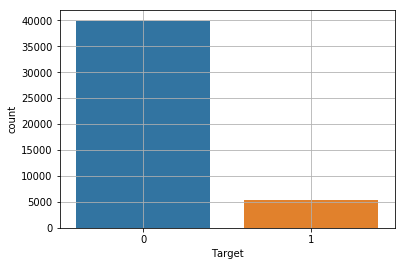

```python
sns.countplot(x='Target', data=bank_dum), plt.grid()
```

It's a unbalanced data

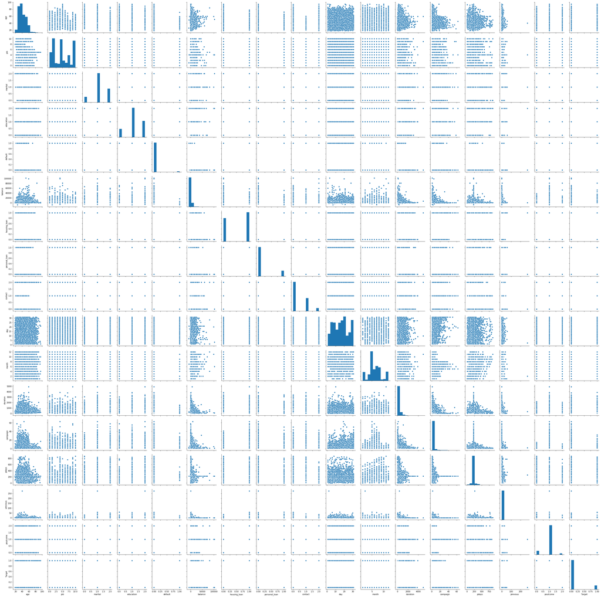

```python
sns.pairplot(bank_new)
```

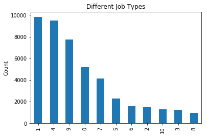

```python
bank_new['job'].value_counts().plot(kind='bar')
plt.title('Different Job Types')
plt.ylabel('Count')
plt.show()
```

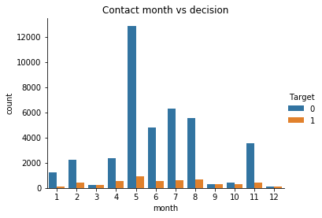

```python
sns.factorplot(data=bank_new, x='month', hue='Target', kind='count')
plt.subplots_adjust(bottom=0.3, top=0.9)
plt.title('Contact month vs decision')
```

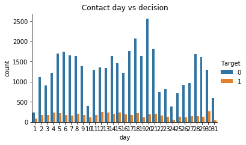

```python
sns.factorplot(data=bank_new, x='day', hue='Target', kind='count')
plt.subplots_adjust(bottom=0.5, top=1)
plt.title('Contact day vs decision')
```

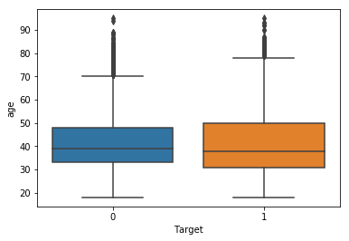

```python
sns.boxplot(x='Target', y='age', data=bank_new)
```

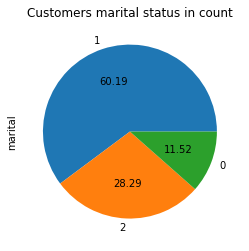

```python
bank_new['marital'].value_counts().plot(kind='pie',autopct='%.2f')
plt.title('Customers marital status in count')
plt.show()
```

```
marital
0    11.517109
1    60.193316
2    28.289576
dtype: float64
```

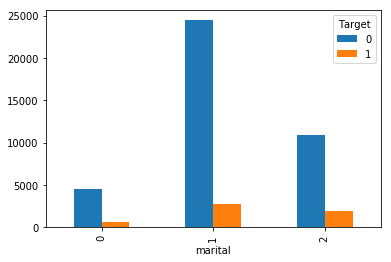

```python
# marital status of customers whose term deposit status
tmp_data = pd.crosstab(bank_new['marital'], bank_new['Target'])
tmp_data.plot(kind='bar')
print(bank_new.groupby(['marital']).size()/len(bank_new)*100)
```

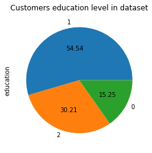

```python
bank_new['education'].value_counts().plot(kind='pie',autopct='%.2f')
plt.title('Customers education level in dataset')
plt.show()
```

```
education
0    15.252925
1    54.537613
2    30.209462
dtype: float64
```

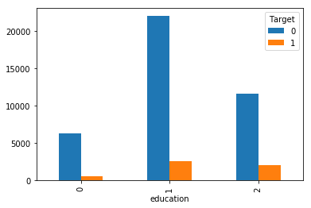

```python
# Education of customers whose term deposit status
tmp_data = pd.crosstab(bank_new['education'], bank_new['Target'])
tmp_data.plot(kind='bar')
print(bank_new.groupby(['education']).size()/len(bank_new)*100)
```

1. From the given dataset, customers with secondary & tertiary level education are more compared to the customers with primary level of education

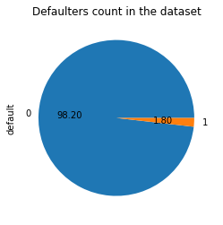

```python
bank_new['default'].value_counts().plot(kind='pie',autopct='%.2f')
plt.title('Defaulters count in the dataset')
plt.show()
```

```
default
0    98.197341
1     1.802659
dtype: float64
```

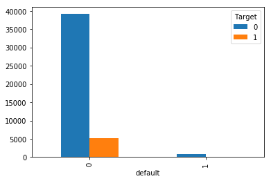

```python
# default customers from the given dataset
tmp_data = pd.crosstab(bank_new['default'], bank_new['Target'])
tmp_data.plot(kind='bar')
print(bank_new.groupby(['default']).size()/len(bank_new)*100)
```

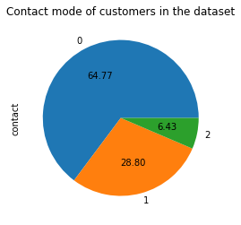

```python
bank_new['contact'].value_counts().plot(kind='pie',autopct='%.2f')
plt.title('Contact mode of customers in the dataset')
plt.show()
```

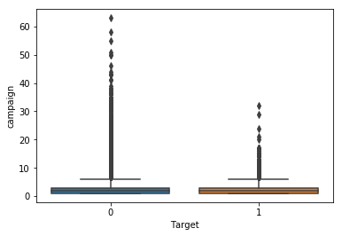

```python
sns.boxplot(x='Target', y='campaign', data=bank_new)
```

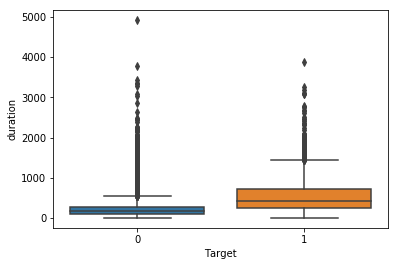

```python
sns.boxplot(x='Target', y='duration', data=bank_new)
```

```python
from scipy.stats import skew
```

```
Skewness of variable age: 0.6847952047866451
```

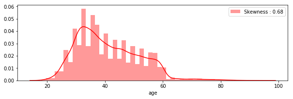

```
Skewness of variable balance: 8.360030947252687
```

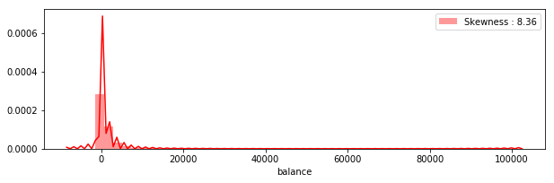

```
Skewness of variable campaign: 4.898487638410557
```

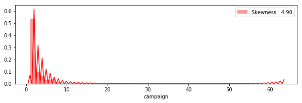

```
Skewness of variable day: 0.09307592583897241
```

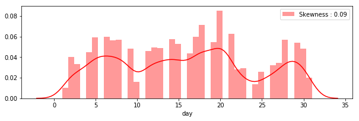

```
Skewness of variable pdays: 1.6503225274395252
```

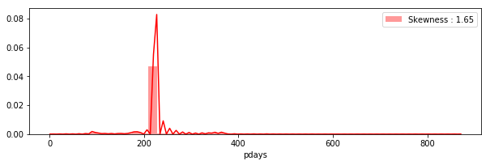

```
Skewness of variable previous: 41.84506608797322
```

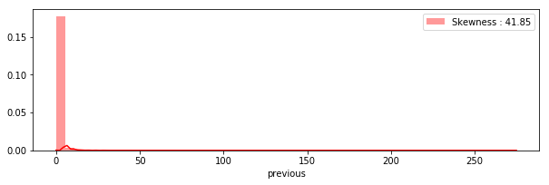

```python
plt.figure(figsize=[10,20])
plt.subplot(611)
g = sns.distplot(bank_new["age"], color="r", label="Skewness : %.2f"%(bank_new["age"].skew()))
print( 'Skewness of variable age: {}'.format( skew(bank_new["age"]) ))
g = g.legend(loc="best")
plt.show()
plt.figure(figsize=[10,20])
plt.subplot(612)
g = sns.distplot(bank_new["balance"], color="r", label="Skewness : %.2f"%(bank_new["balance"].skew()))
print( 'Skewness of variable balance: {}'.format( skew(bank_new["balance"]) ))
g = g.legend(loc="best")
plt.show()
plt.figure(figsize=[10,20])
plt.subplot(613)
g = sns.distplot(bank_new["campaign"], color="r", label="Skewness : %.2f"%(bank_new["campaign"].skew()))
print( 'Skewness of variable campaign: {}'.format( skew(bank_new["campaign"]) ))
g = g.legend(loc="best")
plt.show()
plt.figure(figsize=[10,20])
plt.subplot(614)
g = sns.distplot(bank_new["day"], color="r", label="Skewness : %.2f"%(bank_new["day"].skew()))
print( 'Skewness of variable day: {}'.format( skew(bank_new["day"]) ))
g = g.legend(loc="best")
plt.show()
plt.figure(figsize=[10,20])
plt.subplot(615)
g = sns.distplot(bank_new["pdays"], color="r", label="Skewness : %.2f"%(bank_new["pdays"].skew()))
print( 'Skewness of variable pdays: {}'.format( skew(bank_new["pdays"]) ))
g = g.legend(loc="best")
plt.show()
plt.figure(figsize=[10,20])
plt.subplot(616)
g = sns.distplot(bank_new["previous"], color="r", label="Skewness : %.2f"%(bank_new["previous"].skew()))
print( 'Skewness of variable previous: {}'.format( skew(bank_new["previous"]) ))
g = g.legend(loc="best")
plt.show()
```

Histogram of continuos variables shows us that none of the variables has a normal distribution.

```python
bank_new.head(2)
```

|  | age | job | marital | education | default | balance | housing_loan | personal_loan | contact | day | month | duration | campaign | pdays | previous | poutcome | Target |
| --- | --- | --- | --- | --- | --- | --- | --- | --- | --- | --- | --- | --- | --- | --- | --- | --- | --- |
| 0 | 58 | 4 | 1 | 2 | 0 | 2143 | 1 | 0 | 1 | 5 | 5 | 261 | 1 | 224 | 0 | 1 | 0 |
| 1 | 44 | 9 | 2 | 1 | 0 | 29 | 1 | 0 | 1 | 5 | 5 | 151 | 1 | 224 | 0 | 1 | 0 |

We can see that the data is very skewed, so we are duplicating the data which has Target as 'yes'

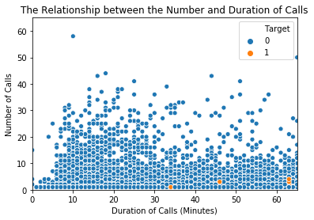

```python
duration_campaign = sns.scatterplot(x='duration', y='campaign',data = bank_new,
                     hue = 'Target')

plt.axis([0,65,0,65])
plt.ylabel('Number of Calls')
plt.xlabel('Duration of Calls (Minutes)')
plt.title('The Relationship between the Number and Duration of Calls')
# Annotation
plt.show()
```

```python
bank_dup = bank_new
b1=bank_dup.copy()
# Target feature is encoded from yes/no to 1/0.
b2=b1[b1['Target']==1]
b1=pd.concat([b1, b2])
b1=pd.concat([b1, b2])
b1=pd.concat([b1, b2])
b1=pd.concat([b1, b2])
b1=pd.concat([b1, b2])
b1=pd.concat([b1, b2])
b1=pd.concat([b1, b2])
bank_dup = b1
```

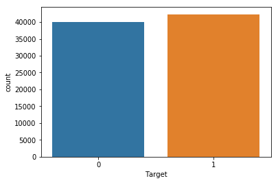

```python
sns.countplot(x='Target',data=bank_dup)
```

1. Now the data looks much more balanced

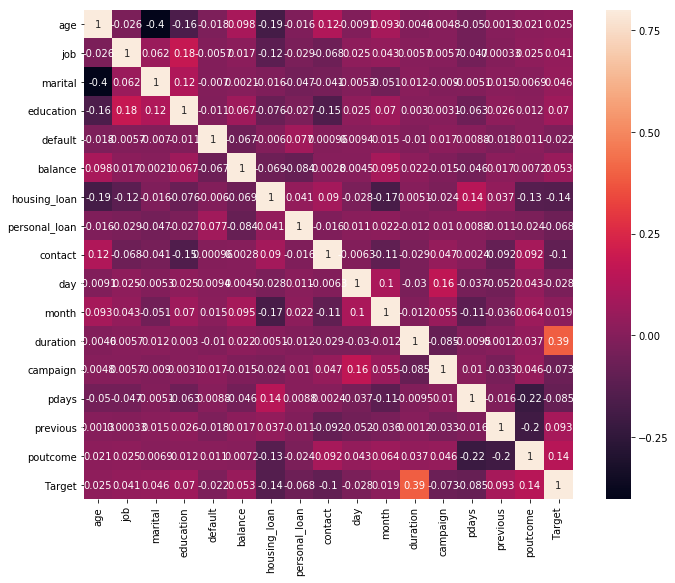

```python
corrmat = bank_new.corr()
f, ax = plt.subplots(figsize=(12, 9))
sns.heatmap(corrmat, vmax=.8, square=True, annot=True);
```

```python
#### Analyzing data distribution by plotting graphs for numerical fields
#header = ['age','campaign','pdays','previous']
#bank_new.hist(column=header,figsize=(10,10))
#plt.subplots_adjust(wspace = 0.5, hspace = 0.5)
#plt.show()

#### From this we can see the data is not evenly distributed, we need to standardize the data.
```

```python
#### Standardizing the data
#idx_numeric=[0,10,11,12,14,15,16,17,18] ### numeric value columns
#scaler = MinMaxScaler()
#bank_new[bank_new.columns[idx_numeric]] = scaler.fit_transform(bank_new[bank_new.columns[idx_numeric]])
#bank_new.head(5)
```

## Models

Split the data for training and test set in the ratio of 70:30 respectively

```python
## Note:
# bank_new has label encoded values for categorical values
# bank_dum has dummies for categorical values
# bank_dup has theTarget 'yes' data duplpicated to match the count with 'No' data.
```

```python
X = bank_new.drop(['Target'], axis=1)
y = bank_new['Target']
test_size = 0.30
seed = 7

X_train, X_test, y_train, y_test = train_test_split(X, y, test_size=test_size, random_state=seed)

# Scaled data
ZX = preprocessing.scale(X)
ZX_train, ZX_test, y_train, y_test = train_test_split(ZX, y, test_size=test_size, random_state=seed)
```

```python
#print ("X_train : ", X_train.count() )
#print ("X_test : ", X_test.count() )
#print ("y_train : ", y_train.count() )
#print ("y_test : ", y_test.count() )
```

```python
def get_model_scores(y_actual, y_predicted):
    print ("Accuracy Score  = ", accuracy_score(y_actual, y_predicted))
    print ("Precision Score = ", precision_score(y_actual, y_predicted))
    print ("Recall Score    = ", recall_score(y_actual, y_predicted))
    pass
```

```python
def get_model_scores_return(y_actual, y_predicted):
    acc = accuracy_score(y_actual, y_predicted)
    prec =  precision_score(y_actual, y_predicted)
    rec =  recall_score(y_actual, y_predicted)

    return acc, prec, rec
```

```python
def get_conf_class_rpt(y_actual, y_predicted):
    print('Confusion Matrix:')
    print(metrics.confusion_matrix(y_actual, y_predicted))
    print('\n')
    print('Classification Report:')
    print(metrics.classification_report(y_actual, y_predicted))
```

```python
#res_df = pd.DataFrame(columns=['Method','Scaled_or_not','Kernel','Train_score','Test_score','Accuracy','Precision','Recall'])
#def result_df(method, sclae_y_n, score_dict):
#    if score_dict:

#    if res_df['Method'] == method:

#    print (res_df)

#result_df()
```

```python
#models = []
#models.append(('LR', LogisticRegression()))
#models.append(('NB', GaussianNB()))
#models.append(('KNN', KNeighborsClassifier()))
#models.append(('SVM', SVC()))
#models.append(('DT', DecisionTreeClassifier()))
#results = []
#names = []
#n_splits = 5
```

### Supervised Learning

#### Logistic Regression

```python
LogR = LogisticRegression()
LogR.fit(X_train, y_train)

y_LR_predict = LogR.predict(X_test)
LogR_Test_Score = LogR.score(X_test, y_test)
LogR_Train_Score = LogR.score(X_train, y_train)

acc, prec, rec = get_model_scores_return(y_test, y_LR_predict)
```

```python
result_df = pd.DataFrame({'Method':['LogR'], 'Scaled_or_not':'Not_scaled', 'Train_score':LogR_Train_Score, 'Test_score':acc, 'Precision':prec, 'Recall':rec},index=[0])

print (result_df)
```

```
  Method Scaled_or_not  Train_score  Test_score  Precision    Recall
0   LogR    Not_scaled     0.893102    0.898039   0.621971  0.250978
```

```python
col=list(X_train.columns)
coef_df = pd.DataFrame(LogR.coef_, columns= col)
coef_df['intercept'] = LogR.intercept_
print('Contribution of features on target value:')
print(coef_df)
```

```
Contribution of features on target value:
        age       job   marital  education   default   balance  housing_loan  \
0  0.006265 -0.000351  0.191241   0.218353 -0.341264  0.000018     -0.850197

   personal_loan   contact       day     month  duration  campaign     pdays  \
0      -0.664585 -0.648454 -0.007351 -0.031496  0.003755 -0.146307 -0.003621

   previous  poutcome  intercept
0  0.128371  0.837203  -2.787924
```

```python
get_model_scores(y_test, y_LR_predict)
```

```
Accuracy Score  =  0.8980389265703332
Precision Score =  0.6219709208400647
Recall Score    =  0.25097783572359844
```

Getting confusion matrix and classification report for better result analysis

```python
get_conf_class_rpt(y_test,y_LR_predict)
```

```
Confusion Matrix:
[[11796   234]
 [ 1149   385]]


Classification Report:
              precision    recall  f1-score   support

           0       0.91      0.98      0.94     12030
           1       0.62      0.25      0.36      1534

   micro avg       0.90      0.90      0.90     13564
   macro avg       0.77      0.62      0.65     13564
weighted avg       0.88      0.90      0.88     13564
```

```python
#from utils import plot_confusion_matrix
#int_to_class = {0: "no", 1: "yes"}
#cnf_matrix = confusion_matrix([int_to_class[c] for c in y_test], [int_to_class[c] for c in y_LR_predict])

## Plot the confusion matrix
#plt.figure()
#plot_confusion_matrix(cnf_matrix, classes=class_names, title='Confusion matrix, with normalization')
#plt.show()
```

```python
# Is our model still predicting just one class?
print( np.unique( y_LR_predict ) )
```

```
[0 1]
```

##### Upsampling the minority class

```python
# Separate majority and minority classes
df_majority = bank_new[bank_new["Target"]==0]
df_minority = bank_new[bank_new["Target"]==1]

# Upsample minority class
df_minority_upsampled = resample(df_minority,
                                 replace=True,     # sample with replacement
                                 n_samples=39922,    # to match majority class
                                 random_state=123) # reproducible results

# Combine majority class with upsampled minority class
df_upsampled = pd.concat([df_majority, df_minority_upsampled])

# Display new class counts
df_upsampled['Target'].value_counts()
```

```
1    39922
0    39922
Name: Target, dtype: int64
```

```python
# Separate input features (X) and target variable (y)
yu = df_upsampled['Target']
XU = df_upsampled.drop('Target', axis=1)

XU_train, XU_test, yu_train, yu_test = train_test_split(XU, yu, test_size=test_size, random_state=seed)

# Train model
LogR_up = LogisticRegression().fit(XU_train, yu_train)

# Predict on training set
y_LogR_up_predict = LogR_up.predict(XU_test)
```

```python
print ("Train score : ", LogR_up.score(XU_train, yu_train))
print ("Test score  : ", LogR_up.score(XU_test, yu_test))
```

```
Train score :  0.8004115226337448
Test score  :  0.8017450112716039
```

```python
get_model_scores(yu_test, y_LogR_up_predict)
```

```
Accuracy Score  =  0.8017450112716039
Precision Score =  0.8155042824681
Recall Score    =  0.7795972930069346
```

```python
acc, prec, rec = get_model_scores_return(yu_test, y_LogR_up_predict)
temp_result_df = pd.DataFrame({'Method':['LogR'], 'Scaled_or_not':'Up_Sampled', 'Train_score':LogR_up.score(XU_train, yu_train), 'Test_score':acc, 'Precision':prec, 'Recall':rec})
result_df = pd.concat([result_df, temp_result_df])
print (result_df)
```

```
  Method Scaled_or_not  Train_score  Test_score  Precision    Recall
0   LogR    Not_scaled     0.893102    0.898039   0.621971  0.250978
0   LogR    Up_Sampled     0.800412    0.801745   0.815504  0.779597
```

```python
# Is our model still predicting just one class?
print( np.unique( y_LogR_up_predict ) )
# [0 1]
```

```
[0 1]
```

```python
# Predict class probabilities
y_LogR_up_predict = LogR_up.predict_proba(XU)

# Keep only the positive class
y_LogR_up_predict = [p[1] for p in y_LogR_up_predict]

y_LogR_up_predict[:5]
```

```
[0.32963240014544165,
 0.1874817498704781,
 0.042931049161261704,
 0.11832702960305017,
 0.42560227104099807]
```

```python
print( roc_auc_score(yu_test, y_LogR_up_predict) )
```

[output not shown]

```python
#get_conf_class_rpt(yu_test, y_LogR_up_predict)
```

#### Gaussian Naive Bayes

```python
NB = GaussianNB()
NB.fit(XU_train, yu_train)
y_NB_predict = NB.predict(XU_test)
y_NB_test_score = NB.score(XU_test, yu_test)
y_NB_train_score = NB.score(XU_train, yu_train)

print ("Train score : ", y_NB_train_score )
print ("Test score  : ", y_NB_test_score )
```

```
Train score :  0.743317230273752
Test score  :  0.7482257660515989
```

```python
get_model_scores(yu_test, y_NB_predict)
```

```
Accuracy Score  =  0.7482257660515989
Precision Score =  0.784932821497121
Recall Score    =  0.6833486506809258
```

```python
get_conf_class_rpt(yu_test, y_NB_predict)
```

```
Confusion Matrix:
[[9744 2241]
 [3790 8179]]


Classification Report:
              precision    recall  f1-score   support

           0       0.72      0.81      0.76     11985
           1       0.78      0.68      0.73     11969

   micro avg       0.75      0.75      0.75     23954
   macro avg       0.75      0.75      0.75     23954
weighted avg       0.75      0.75      0.75     23954
```

```python
acc, prec, rec = get_model_scores_return(yu_test, y_NB_predict)
temp_result_df = pd.DataFrame({'Method':['Naive Bayes'], 'Scaled_or_not':'Up_Sampled', 'Train_score':y_NB_train_score, 'Test_score':acc, 'Precision':prec, 'Recall':rec})
result_df = pd.concat([result_df, temp_result_df])
print (result_df)
```

```
        Method Scaled_or_not  Train_score  Test_score  Precision    Recall
0         LogR    Not_scaled     0.893102    0.898039   0.621971  0.250978
0         LogR    Up_Sampled     0.800412    0.801745   0.815504  0.779597
0  Naive Bayes    Up_Sampled     0.743317    0.748226   0.784933  0.683349
0  Naive Bayes    Up_Sampled     0.743317    0.748226   0.784933  0.683349
```

#### K-Nearest Neighbor

```python
# creating odd list of K for KNN
myList = list(range(1,10))

# subsetting just the odd ones
neighbors = list(filter(lambda x: x % 2 != 0, myList))
```

```python
# empty list that will hold accuracy scores
knn_ac_scores = []

# perform accuracy metrics for values from 1,3,5....19
for k in neighbors:
    knn = KNeighborsClassifier(n_neighbors=k)
    knn.fit(XU_train, yu_train)
    # predict the response
    y_knn_pred = knn.predict(XU_test)
    # evaluate accuracy
    scores = accuracy_score(yu_test, y_knn_pred)
    knn_ac_scores.append(scores)

# changing to misclassification error
MSE = [1 - x for x in knn_ac_scores]

print (MSE)

# determining best k
optimal_k = neighbors[MSE.index(min(MSE))]
print("The optimal number of neighbors is %d" % optimal_k)
```

```
[0.054061952074810016, 0.09263588544710699, 0.12448860315604915, 0.15179093262085663, 0.17020121900308927]
The optimal number of neighbors is 1
```

### This part needs to be automated, that optimal value should be loaded back and that should be feeded to dataframe as a result -- pending

```python
n_knn = KNeighborsClassifier(n_neighbors=optimal_k)
n_knn.fit(XU_train, yu_train)
y_n_knn_predict = n_knn.predict(XU_test)
knn_test_score = n_knn.score(XU_test,yu_test)
knn_train_score = n_knn.score(XU_train, yu_train)
```

```python
print ("KNN Test Score : ", knn_test_score)
print ("KNN Train Score : ", knn_train_score)
```

```
KNN Test Score :  0.94593804792519
KNN Train Score :  1.0
```

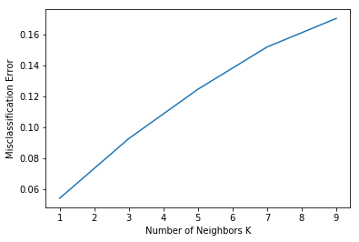

```python
plt.plot(neighbors, MSE)
plt.xlabel('Number of Neighbors K')
plt.ylabel('Misclassification Error')
plt.show()
```

```python
get_model_scores(yu_test, y_n_knn_predict)
```

```
Accuracy Score  =  0.94593804792519
Precision Score =  0.9039509536784741
Recall Score    =  0.99782772161417
```

```python
acc, prec, rec = get_model_scores_return(yu_test, y_n_knn_predict)
temp_result_df = pd.DataFrame({'Method':['KNN'], 'Scaled_or_not':'Up_Sampled', 'Train_score':knn_train_score, 'Test_score':acc, 'Precision':prec, 'Recall':rec})
result_df = pd.concat([result_df, temp_result_df])
print (result_df)
```

```
        Method Scaled_or_not  Train_score  Test_score  Precision    Recall
0         LogR    Not_scaled     0.893102    0.898039   0.621971  0.250978
0         LogR    Up_Sampled     0.800412    0.801745   0.815504  0.779597
0  Naive Bayes    Up_Sampled     0.743317    0.748226   0.784933  0.683349
0  Naive Bayes    Up_Sampled     0.743317    0.748226   0.784933  0.683349
0          KNN    Up_Sampled     1.000000    0.945938   0.903951  0.997828
```

```python
get_conf_class_rpt(yu_test, y_n_knn_predict)
```

```
Confusion Matrix:
[[10716  1269]
 [   26 11943]]


Classification Report:
              precision    recall  f1-score   support

           0       1.00      0.89      0.94     11985
           1       0.90      1.00      0.95     11969

   micro avg       0.95      0.95      0.95     23954
   macro avg       0.95      0.95      0.95     23954
weighted avg       0.95      0.95      0.95     23954
```

#### Support Vector Machine

```python
### NOT RUNNING THIS SVM NOW. TAKING MORE TIME
```

```python
# Building a Support Vector Machine on train data
for k in  ['linear','rbf','sigmoid']: #poly - ignoring this as it takes time and the result is not better than linear/rbf
    svc_model= SVC(kernel=k)
    svc_model.fit(XU_train, yu_train)

    y_svm_predict = svc_model.predict(XU_test)

    # check the accuracy on the training set
    svm_train_score = svc_model.score(XU_train, yu_train)
    svm_test_score = svc_model.score(XU_test, yu_test)

    print ("SVM train score {} for kernel {} ".format(svm_train_score, k))
    print ("SVM test score {} for kernel {} ".format(svm_test_score, k))
```

[output not shown]

```python
get_conf_class_rpt(y_test, y_svm_predict)
```

[output not shown]

### Ensemble Techniques

#### Decision Tree

```python
from sklearn.feature_extraction.text import CountVectorizer  #DT does not take strings as input for the model fit step....
```

```python
# Decision tree in Python can take only numerical / categorical colums. It cannot take string / obeject types.
# The following code loops through each column and checks if the column type is object then converts those columns
# into categorical with each distinct value becoming a category or code.

#for feature in bank_new.columns: # Loop through all columns in the dataframe
#    if bank_new[feature].dtype == 'object': # Only apply for columns with categorical strings
#        bank_new[feature] = pd.Categorical(bank_new[feature]).codes # Replace strings with an integer
```

```python
dt_model = DecisionTreeClassifier(criterion = 'entropy' )
dt_model.fit(XU_train, yu_train)
```

```
DecisionTreeClassifier(class_weight=None, criterion='entropy', max_depth=None,
            max_features=None, max_leaf_nodes=None,
            min_impurity_decrease=0.0, min_impurity_split=None,
            min_samples_leaf=1, min_samples_split=2,
            min_weight_fraction_leaf=0.0, presort=False, random_state=None,
            splitter='best')
```

```python
from IPython.display import Image
#import pydotplus as pydot
from sklearn import tree
from os import system

bank_new_File = open('F:\df_bank_new.dot','w')
dot_data = tree.export_graphviz(dt_model, out_file=bank_new_File, feature_names = list(XU_train), class_names = list(yu_train))

bank_new_File.close()


# importance of features in the tree building ( The importance of a feature is computed as the
#(normalized) total reduction of the criterion brought by that feature. It is also known as the Gini importance )

print (pd.DataFrame(dt_model.feature_importances_, columns = ["Imp"], index = XU_train.columns))
```

[output not shown]

```python
# You can also copy the script in the .dot file and paste it at http://webgraphviz.com/ to get tree view
#or create a .png as below

system("dot -Tpng F:\bank_new.dot -o F:/bank_new.png")
Image("F:\bank_new.png")
```

[output not shown]

```python
y_DT_predict = dt_model.predict(XU_test)
```

```python
print(dt_model.score(XU_train , yu_train))
print(dt_model.score(XU_test , yu_test))
```

```
1.0
0.9571261584704016
```

```python
get_conf_class_rpt(yu_test, y_DT_predict)
```

```
Confusion Matrix:
[[10981  1004]
 [   23 11946]]


Classification Report:
              precision    recall  f1-score   support

           0       1.00      0.92      0.96     11985
           1       0.92      1.00      0.96     11969

   micro avg       0.96      0.96      0.96     23954
   macro avg       0.96      0.96      0.96     23954
weighted avg       0.96      0.96      0.96     23954
```

```python
get_model_scores(yu_test, y_DT_predict)
```

[output not shown]

```python
acc, prec, rec = get_model_scores_return(yu_test, y_DT_predict)
temp_result_df = pd.DataFrame({'Method':['Decision Tree'], 'Scaled_or_not':'Up_Sampled', 'Train_score':dt_model.score(XU_train , yu_train), 'Test_score':acc, 'Precision':prec, 'Recall':rec})
result_df = pd.concat([result_df, temp_result_df])
print (result_df)
```

```
          Method Scaled_or_not  Train_score  Test_score  Precision    Recall
0           LogR    Not_scaled     0.893102    0.898039   0.621971  0.250978
0           LogR    Up_Sampled     0.800412    0.801745   0.815504  0.779597
0    Naive Bayes    Up_Sampled     0.743317    0.748226   0.784933  0.683349
0    Naive Bayes    Up_Sampled     0.743317    0.748226   0.784933  0.683349
0            KNN    Up_Sampled     1.000000    0.945938   0.903951  0.997828
0  Decision Tree    Up_Sampled     1.000000    0.957126   0.922471  0.998078
```

```python
## including - max_depth = 7 in DecisionTreeClassifier(max_depth,criterion)
```

#### Bagging

```python
bgcl = BaggingClassifier(base_estimator=dt_model, n_estimators=10)

#bgcl = BaggingClassifier(n_estimators=50)
bgcl = bgcl.fit(XU_train, yu_train)
```

```python
y_BG_predict = bgcl.predict(XU_test)

print ("Bagging train score : ", bgcl.score(XU_train, yu_train))
print ("Bagging test score : ", bgcl.score(XU_test, yu_test))
```

```
Bagging train score :  0.9989443549830024
Bagging test score :  0.9618852801202304
```

```python
get_model_scores(yu_test, y_BG_predict)
```

```
Accuracy Score  =  0.9618852801202304
Precision Score =  0.9305295950155763
Recall Score    =  0.9982454674575988
```

```python
get_conf_class_rpt(yu_test, y_BG_predict)
```

```
Confusion Matrix:
[[11093   892]
 [   21 11948]]


Classification Report:
              precision    recall  f1-score   support

           0       1.00      0.93      0.96     11985
           1       0.93      1.00      0.96     11969

   micro avg       0.96      0.96      0.96     23954
   macro avg       0.96      0.96      0.96     23954
weighted avg       0.96      0.96      0.96     23954
```

```python
acc, prec, rec = get_model_scores_return(yu_test, y_BG_predict)
temp_result_df = pd.DataFrame({'Method':['Bagging'], 'Scaled_or_not':'Up_Sampled', 'Train_score':bgcl.score(XU_train, yu_train), 'Test_score':acc, 'Precision':prec, 'Recall':rec})
result_df = pd.concat([result_df, temp_result_df])
print (result_df)
```

```
          Method Scaled_or_not  Train_score  Test_score  Precision    Recall
0           LogR    Not_scaled     0.893102    0.898039   0.621971  0.250978
0           LogR    Up_Sampled     0.800412    0.801745   0.815504  0.779597
0    Naive Bayes    Up_Sampled     0.743317    0.748226   0.784933  0.683349
0    Naive Bayes    Up_Sampled     0.743317    0.748226   0.784933  0.683349
0            KNN    Up_Sampled     1.000000    0.945938   0.903951  0.997828
0  Decision Tree    Up_Sampled     1.000000    0.957126   0.922471  0.998078
0        Bagging    Up_Sampled     0.998944    0.961885   0.930530  0.998245
```

#### AdaBoost

```python
abcl = AdaBoostClassifier(base_estimator=dt_model, n_estimators=10)
#abcl = AdaBoostClassifier( n_estimators=50)
abcl = abcl.fit(XU_train, yu_train)
```

```python
y_ada_predict = abcl.predict(XU_test)

print ("AdaBoost train score : ", abcl.score(XU_train, yu_train))
print ("AdaBoost test score : ", abcl.score(XU_test, yu_test))
```

```
AdaBoost train score :  1.0
AdaBoost test score :  0.9573348918760959
```

```python
get_model_scores(yu_test, y_ada_predict)
```

```
Accuracy Score  =  0.9573348918760959
Precision Score =  0.9228926833037163
Recall Score    =  0.9979948199515415
```

```python
get_conf_class_rpt(yu_test, y_ada_predict)
```

```
Confusion Matrix:
[[10987   998]
 [   24 11945]]


Classification Report:
              precision    recall  f1-score   support

           0       1.00      0.92      0.96     11985
           1       0.92      1.00      0.96     11969

   micro avg       0.96      0.96      0.96     23954
   macro avg       0.96      0.96      0.96     23954
weighted avg       0.96      0.96      0.96     23954
```

```python
acc, prec, rec = get_model_scores_return(yu_test, y_ada_predict)
temp_result_df = pd.DataFrame({'Method':['AdaBoost'], 'Scaled_or_not':'Up_Sampled', 'Train_score':abcl.score(XU_train, yu_train), 'Test_score':acc, 'Precision':prec, 'Recall':rec})
result_df = pd.concat([result_df, temp_result_df])
print (result_df)
```

```
          Method Scaled_or_not  Train_score  Test_score  Precision    Recall
0           LogR    Not_scaled     0.893102    0.898039   0.621971  0.250978
0           LogR    Up_Sampled     0.800412    0.801745   0.815504  0.779597
0    Naive Bayes    Up_Sampled     0.743317    0.748226   0.784933  0.683349
0    Naive Bayes    Up_Sampled     0.743317    0.748226   0.784933  0.683349
0            KNN    Up_Sampled     1.000000    0.945938   0.903951  0.997828
0  Decision Tree    Up_Sampled     1.000000    0.957126   0.922471  0.998078
0        Bagging    Up_Sampled     0.998944    0.961885   0.930530  0.998245
0       AdaBoost    Up_Sampled     1.000000    0.957335   0.922893  0.997995
```

#### GradientBoost

```python
gbcl = GradientBoostingClassifier(n_estimators = 10)
gbcl = gbcl.fit(XU_train, yu_train)
```

```python
y_GD_predict = gbcl.predict(XU_test)

print ("GradientBoost train score : ", gbcl.score(XU_train, yu_train))
print ("GradientBoost test score : ", gbcl.score(XU_test, yu_test))
```

```
GradientBoost train score :  0.8012166756128108
GradientBoost test score :  0.799240210403273
```

```python
get_model_scores(yu_test, y_GD_predict)
```

```
Accuracy Score  =  0.799240210403273
Precision Score =  0.8028764805414551
Recall Score    =  0.7928816108279723
```

```python
get_conf_class_rpt(yu_test, y_GD_predict)
```

```
Confusion Matrix:
[[9655 2330]
 [2479 9490]]


Classification Report:
              precision    recall  f1-score   support

           0       0.80      0.81      0.80     11985
           1       0.80      0.79      0.80     11969

   micro avg       0.80      0.80      0.80     23954
   macro avg       0.80      0.80      0.80     23954
weighted avg       0.80      0.80      0.80     23954
```

```python
acc, prec, rec = get_model_scores_return(yu_test, y_GD_predict)
temp_result_df = pd.DataFrame({'Method':['GraientBoost'], 'Scaled_or_not':'Up_Sampled', 'Train_score':gbcl.score(XU_train, yu_train), 'Test_score':acc, 'Precision':prec, 'Recall':rec})
result_df = pd.concat([result_df, temp_result_df])
print (result_df)
```

```
          Method Scaled_or_not  Train_score  Test_score  Precision    Recall
0           LogR    Not_scaled     0.893102    0.898039   0.621971  0.250978
0           LogR    Up_Sampled     0.800412    0.801745   0.815504  0.779597
0    Naive Bayes    Up_Sampled     0.743317    0.748226   0.784933  0.683349
0    Naive Bayes    Up_Sampled     0.743317    0.748226   0.784933  0.683349
0            KNN    Up_Sampled     1.000000    0.945938   0.903951  0.997828
0  Decision Tree    Up_Sampled     1.000000    0.957126   0.922471  0.998078
0        Bagging    Up_Sampled     0.998944    0.961885   0.930530  0.998245
0       AdaBoost    Up_Sampled     1.000000    0.957335   0.922893  0.997995
0   GraientBoost    Up_Sampled     0.801217    0.799240   0.802876  0.792882
```

#### Ramdom Forest

```python
rfcl = RandomForestClassifier(n_estimators = 10)
rfcl = rfcl.fit(XU_train, yu_train)
```

```python
y_RF_predict = rfcl.predict(XU_test)

print ("RandomForest train score : ", rfcl.score(XU_train, yu_train))
print ("RandomForest test score : ", rfcl.score(XU_test, yu_test))
```

```
RandomForest train score :  0.9993558776167472
RandomForest test score :  0.9681890289721967
```

```python
get_model_scores(yu_test, y_RF_predict)
```

```
Accuracy Score  =  0.9681890289721967
Precision Score =  0.9422302896377555
Recall Score    =  0.9974935249394269
```

```python
get_conf_class_rpt(yu_test, y_RF_predict)
```

```
Confusion Matrix:
[[11253   732]
 [   30 11939]]


Classification Report:
              precision    recall  f1-score   support

           0       1.00      0.94      0.97     11985
           1       0.94      1.00      0.97     11969

   micro avg       0.97      0.97      0.97     23954
   macro avg       0.97      0.97      0.97     23954
weighted avg       0.97      0.97      0.97     23954
```

```python
acc, prec, rec = get_model_scores_return(yu_test, y_RF_predict)
temp_result_df = pd.DataFrame({'Method':['RandomForest'], 'Scaled_or_not':'Up_Sampled', 'Train_score':rfcl.score(XU_train, yu_train), 'Test_score':acc, 'Precision':prec, 'Recall':rec})
result_df = pd.concat([result_df, temp_result_df])
print (result_df)
```

```
          Method Scaled_or_not  Train_score  Test_score  Precision    Recall
0           LogR    Not_scaled     0.893102    0.898039   0.621971  0.250978
0           LogR    Up_Sampled     0.800412    0.801745   0.815504  0.779597
0    Naive Bayes    Up_Sampled     0.743317    0.748226   0.784933  0.683349
0    Naive Bayes    Up_Sampled     0.743317    0.748226   0.784933  0.683349
0            KNN    Up_Sampled     1.000000    0.945938   0.903951  0.997828
0  Decision Tree    Up_Sampled     1.000000    0.957126   0.922471  0.998078
0        Bagging    Up_Sampled     0.998944    0.961885   0.930530  0.998245
0       AdaBoost    Up_Sampled     1.000000    0.957335   0.922893  0.997995
0   GraientBoost    Up_Sampled     0.801217    0.799240   0.802876  0.792882
0   RandomForest    Up_Sampled     0.999356    0.968189   0.942230  0.997494
```

#### Best of all models

```python
result_df
```

|  | Method | Scaled_or_not | Train_score | Test_score | Precision | Recall |
| --- | --- | --- | --- | --- | --- | --- |
| 0 | LogR | Not_scaled | 0.893102 | 0.898039 | 0.621971 | 0.250978 |
| 0 | LogR | Up_Sampled | 0.800412 | 0.801745 | 0.815504 | 0.779597 |
| 0 | Naive Bayes | Up_Sampled | 0.743317 | 0.748226 | 0.784933 | 0.683349 |
| 0 | Naive Bayes | Up_Sampled | 0.743317 | 0.748226 | 0.784933 | 0.683349 |
| 0 | KNN | Up_Sampled | 1.000000 | 0.945938 | 0.903951 | 0.997828 |
| 0 | Decision Tree | Up_Sampled | 1.000000 | 0.957126 | 0.922471 | 0.998078 |
| 0 | Bagging | Up_Sampled | 0.998944 | 0.961885 | 0.930530 | 0.998245 |
| 0 | AdaBoost | Up_Sampled | 1.000000 | 0.957335 | 0.922893 | 0.997995 |
| 0 | GraientBoost | Up_Sampled | 0.801217 | 0.799240 | 0.802876 | 0.792882 |
| 0 | RandomForest | Up_Sampled | 0.999356 | 0.968189 | 0.942230 | 0.997494 |

Random Forst and Bagging has given the better result comparitely than other models

### Conclusion

1. Here we have upsampled the minority class and performed models on the same. 2. Without upsampling the result looks one-sided. 3. Random Forest and Bagging performed with same number of estimators has better results 4. Performing these models with undersampling the majority class will also show us the comparetive analysis on results. 5. Here we have used the Label encoded categorical data for performing the models.